# A really bad experiment

Imagine that I have a machine that records static noise from the atmosphere and convert it to two values (x and y).

On two different nights I recorded the following data (night A and B)

```r
library(tidyverse)

df <- read_tsv(file = "t4.dataset.bad_data_permutation.tsv")
```

> Q4.1 How many datapoints did I collect in total?

> Q4.2 How many datapoints did I collect in group A?

> Q4.3 What is the mean x value in group A?

> Q4.4 What is the absolute difference in means of x in the two groups?

Hint: abs(-3.5) = 3.5

———!begin suggested answer ————————

```r
answer <- tibble()
result <- nrow(df)

answer <- rbind(answer,tibble(
  question    = "1",
  true_answer = nrow(df),
  type        = "numeric",
  points      = 1,
  tolerance   = 0.1))

answer <- rbind(answer,tibble(
  question    = "2",
  true_answer = sum(df$group=="A"),
  type        = "numeric",
  points      = 1,
  tolerance   = 0.1))

df2 <- df %>% filter(group=="A")

answer <- rbind(answer,tibble(
  question    = "3",
  true_answer = mean(df2$x),
  type        = "numeric",
  points      = 2,
  tolerance   = 0.01))

g1 <- df %>% filter(group=="A")
g2 <- df %>% filter(group=="B")
result <- abs(mean(g1$x)-mean(g2$x))

answer <- rbind(answer,tibble(
  question    = "4",
  true_answer = result,
  type        = "numeric",
  points      = 2,
  tolerance   = 0.01))

answer
```

```
## # A tibble: 4 x 5
##   question true_answer type    points tolerance
##   <chr>          <dbl> <chr>    <dbl>     <dbl>
## 1 1             295    numeric      1      0.1
## 2 2             163    numeric      1      0.1
## 3 3              60.4  numeric      2      0.01
## 4 4               5.79 numeric      2      0.01
```

———!end suggested answer ————————

Make a scatterplot of x and y for the two groups separatedly.

> Q4.5 What number is hidden in group A?

> Q4.6 What number is hidden in group B?

———!begin suggested answer ————————

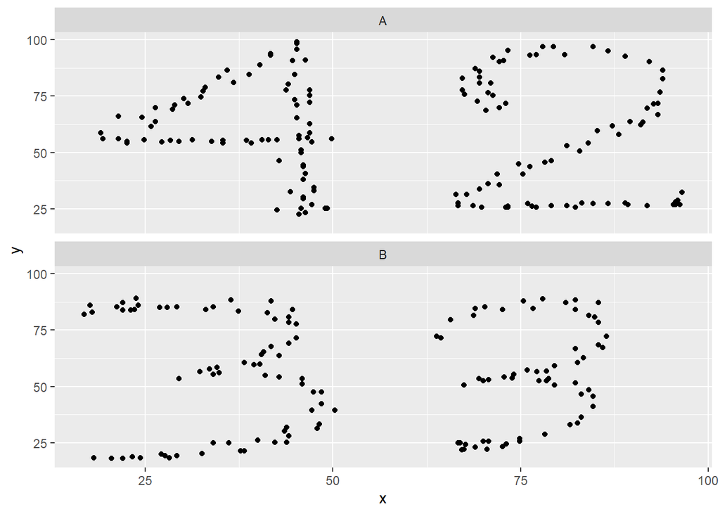

```r
ggplot(df, aes(x=x, y=y)) +
  geom_point() +
  facet_wrap(~group, ncol=1) +
  NULL
```

```r
answer <- rbind(answer, tibble(
  question    = "5",
  true_answer = 42,
  type        = "numeric",
  points      = 2,
  tolerance   = 0.01)
  )

answer <- rbind(answer, tibble(
  question    = "6",
  true_answer = 33,
  type        = "numeric",
  points      = 2,
  tolerance   = 0.01)
  )
```

———!end suggested answer ————————

After looking at the data we can see that the x values are NOT normally distrited.

Despite the peculiar results above we try and look for other patterns in the data.

We specifically try to test if mean(x) is different in night A versus night B.

If we try and do a simple t.test (assuming equal variance in the two groups) we get:

```r
groupA <- df %>% filter(group=="A")
groupB <- df %>% filter(group=="B")

t.test(x = groupA$x,y = groupB$x, var.equal = T)
```

```
##
##  Two Sample t-test
##
## data:  groupA$x and groupB$x
## t = 2.2186, df = 293, p-value = 0.02728
## alternative hypothesis: true difference in means is not equal to 0
## 95 percent confidence interval:
##   0.653959 10.929726
## sample estimates:
## mean of x mean of y
##  60.42665  54.63481
```

> Q4.7 What is the p value we get from this bad test?

———!begin suggested answer ————————

```r
groupA <- df %>% filter(group=="A")
groupB <- df %>% filter(group=="B")
x <- t.test(x = groupA$x,y = groupB$x, var.equal = T)

answer <- rbind(answer, tibble(
  question    = "7",
  true_answer = x$p.value,
  type        = "numeric",
  points      = 3,
  tolerance   = 0.01)
)
```

———!end suggested answer ————————

I really do not trust my test.

So I go ahead and make a permutation test using the following simple code (only 100 permutations)

```r
set.seed(0)
permuted   <- rep(NA, 100)
for (i in 1:length(permuted)) {
  xvalues <- sample(df$x)
  g1 <- mean(xvalues[df$group=="A"])
  g2 <- mean(xvalues[df$group=="B"])
  permuted[i] <- abs(g1 - g2)
}

permuted
```

```
##   [1] 1.55317275 2.68568869 2.10322792 0.43962597 4.76900612 1.16161811 1.94271245 1.06110203 0.74833197
##  [10] 0.57349082 2.52919941 2.34298223 3.31835403 1.09306353 1.54252191 3.60483815 5.58079326 1.61892826
##  [19] 0.51590256 2.15022199 3.24314134 2.67570173 0.80608148 1.71384595 3.15744042 0.93880073 4.67019567
##  [28] 1.25330554 4.87771460 2.58806463 1.49700543 0.04091773 2.04058288 1.06538788 2.95593170 2.04859343
##  [37] 2.60919175 0.97097323 0.25041309 9.03593182 2.13888106 0.97032550 2.68910579 1.74861261 0.25207386
##  [46] 2.67782143 1.07243120 1.14833078 3.94746843 1.18105404 3.80145413 3.25671899 1.68497966 2.64853813
##  [55] 0.74523887 0.56804189 1.13302431 1.99779638 2.41185138 0.41199586 0.20277149 1.70459078 3.80972008
##  [64] 2.33596975 3.16148662 1.27769436 0.75208945 2.61031672 2.41144573 3.62572078 3.64404153 2.16840785
##  [73] 2.78163093 5.46860285 0.40894165 0.28991866 1.52231024 2.84672598 3.15462339 2.74707166 3.55477760
##  [82] 0.32230093 0.56520172 3.05053595 1.80975681 1.14376976 4.42466956 1.28778465 2.08287399 2.35127469
##  [91] 1.60222951 1.86528022 1.58204154 0.70683744 1.08043069 0.81374972 1.06282151 1.27438777 1.20208722
## [100] 5.33157145
```

> Q4.8 How many of the 100 permutations were equal to or more extreme than the observed difference?

———!begin suggested answer ————————

```r
xvalues <- df$x
g1 <- mean(xvalues[df$group=="A"])
g2 <- mean(xvalues[df$group=="B"])
observed <- abs(g1 - g2)

set.seed(0)
permuted   <- rep(NA, 100)
for (i in 1:length(permuted)) {
  xvalues <- sample(df$x)
  g1 <- mean(xvalues[df$group=="A"])
  g2 <- mean(xvalues[df$group=="B"])
  permuted[i] <- abs(g1 - g2)
}

result <- sum(permuted >= observed)

answer <- rbind(answer, tibble(
  question    = "8",
  true_answer = result,
  type        = "numeric",
  points      = 3,
  tolerance   = 0.1)
)
```

———!end suggested answer ————————

> Q4.9 What is the estimated p value based on 5000 permutations?

———!begin suggested answer ————————

```r
xvalues <- df$x
g1 <- mean(xvalues[df$group=="A"])
g2 <- mean(xvalues[df$group=="B"])
observed <- abs(g1 - g2)

set.seed(0)
permuted   <- rep(NA, 5000)
for (i in 1:length(permuted)) {
  xvalues <- sample(df$x)
  g1 <- mean(xvalues[df$group=="A"])
  g2 <- mean(xvalues[df$group=="B"])
  permuted[i] <- abs(g1 - g2)
}

pvalue <- (sum(permuted >= observed) +1 ) / ( length(permuted) +1)

answer <- rbind(answer, tibble(
  question    = "9",
  true_answer = pvalue,
  type        = "numeric",
  points      = 3,
  tolerance   = 0.01)
)
```

———!end suggested answer ————————

———!begin suggested answer ————————

## Hard coded information

```r
topic             <- "t4"  # If you change this to e.g. 2 - you should search & replace all >Q4. with >Q2.
topic_description <- "# Bad data and permutations"
file_description  <- "bad_data_permutation"
```

## Answers table

```r
answer
```

```
## # A tibble: 9 x 5
##   question true_answer type    points tolerance
##   <chr>          <dbl> <chr>    <dbl>     <dbl>
## 1 1           295      numeric      1      0.1
## 2 2           163      numeric      1      0.1
## 3 3            60.4    numeric      2      0.01
## 4 4             5.79   numeric      2      0.01
## 5 5            42      numeric      2      0.01
## 6 6            33      numeric      2      0.01
## 7 7             0.0273 numeric      3      0.01
## 8 8             1      numeric      3      0.1
## 9 9             0.0286 numeric      3      0.01
```

## Saving exam files

```r
answer$question   <- paste(topic, ".", answer$question, sep="") # Reformat column

# Save answer sheet for students to fill out (including points)
x <- paste("answer$", answer$question, " = NA # (",answer$points," points)",sep="")

answer_filename <- paste("exam_answer_sheet.",topic, ".", file_description, ".txt", sep="")
write_lines(topic_description, path = answer_filename)
write_lines(x, path =answer_filename, append = T)

# Save answer key for grading
key_filename <- paste("answer.key.",topic, ".", file_description, ".tsv", sep="")
write_tsv(x = answer, path = key_filename)
```

———!end suggested answer ————————